# SOURCE CODE

```python
#importing libraries:
import numpy
import pandas
import matplotlib.pyplot
import seaborn
import warnings
```

```python
warnings.filterwarnings('ignore')
```

```python
#importing dataset:
Dataset=pandas.read_csv(r"C:\Users\venka\Downloads\cybersecurity_attacks.csv")
Dataset.head()
```

|  | Timestamp | Source IP Address | Destination IP Address | Source Port | Destination Port | Protocol | Packet Length | Packet Type | Traffic Type | Payload Data | ... | Action Taken | Severity Level | User Information | Device Information | Network Segment | Geo-location Data | Proxy Information | Firewall Logs | IDS/IPS Alerts | Log Source |
| --- | --- | --- | --- | --- | --- | --- | --- | --- | --- | --- | --- | --- | --- | --- | --- | --- | --- | --- | --- | --- | --- |
| 0 | 2023-05-30 06:33:58 | 103.216.15.12 | 84.9.164.252 | 31225 | 17616 | ICMP | 503 | Data | HTTP | Qui natus odio asperiores nam. Optio nobis ius... | ... | Logged | Low | Reyansh Dugal | Mozilla/5.0 (compatible; MSIE 8.0; Windows NT ... | Segment A | Jamshedpur, Sikkim | 150.9.97.135 | Log Data | NaN | Server |
| 1 | 2020-08-26 07:08:30 | 78.199.217.198 | 66.191.137.154 | 17245 | 48166 | ICMP | 1174 | Data | HTTP | Aperiam quos modi officiis veritatis rem. Omni... | ... | Blocked | Low | Sumer Rana | Mozilla/5.0 (compatible; MSIE 8.0; Windows NT ... | Segment B | Bilaspur, Nagaland | NaN | Log Data | NaN | Firewall |
| 2 | 2022-11-13 08:23:25 | 63.79.210.48 | 198.219.82.17 | 16811 | 53600 | UDP | 306 | Control | HTTP | Perferendis sapiente vitae soluta. Hic delectu... | ... | Ignored | Low | Himmat Karpe | Mozilla/5.0 (compatible; MSIE 9.0; Windows NT ... | Segment C | Bokaro, Rajasthan | 114.133.48.179 | Log Data | Alert Data | Firewall |
| 3 | 2023-07-02 10:38:46 | 163.42.196.10 | 101.228.192.255 | 20018 | 32534 | UDP | 385 | Data | HTTP | Totam maxime beatae expedita explicabo porro l... | ... | Blocked | Medium | Fateh Kibe | Mozilla/5.0 (Macintosh; PPC Mac OS X 10_11_5; ... | Segment B | Jaunpur, Rajasthan | NaN | NaN | Alert Data | Firewall |
| 4 | 2023-07-16 13:11:07 | 71.166.185.76 | 189.243.174.238 | 6131 | 26646 | TCP | 1462 | Data | DNS | Odit nesciunt dolorem nisi iste iusto. Animi v... | ... | Blocked | Low | Dhanush Chad | Mozilla/5.0 (compatible; MSIE 5.0; Windows NT ... | Segment C | Anantapur, Tripura | 149.6.110.119 | NaN | Alert Data | Firewall |

5 rows × 25 columns

### Data preprocessing

```python
# DATA PREPROCESSING:
Dataset.info()
Dataset.shape
Dataset.describe()
Dataset.nunique()
Dataset['Log Source'].unique()
```

```
<class 'pandas.core.frame.DataFrame'>
RangeIndex: 40000 entries, 0 to 39999
Data columns (total 25 columns):
 #   Column                  Non-Null Count  Dtype
---  ------                  --------------  -----
 0   Timestamp               40000 non-null  object
 1   Source IP Address       40000 non-null  object
 2   Destination IP Address  40000 non-null  object
 3   Source Port             40000 non-null  int64
 4   Destination Port        40000 non-null  int64
 5   Protocol                40000 non-null  object
 6   Packet Length           40000 non-null  int64
 7   Packet Type             40000 non-null  object
 8   Traffic Type            40000 non-null  object
 9   Payload Data            40000 non-null  object
```

[output cut: 17 more lines]

```
array(['Server', 'Firewall'], dtype=object)
```

### DATA CLEANING:

```python
# DATA CLEANING:
Dataset.isnull().sum()
Dataset.duplicated().sum()
Dataset.fillna(numpy.mean,inplace=True)
Dataset.isnull().sum()
Dataset['Log Source'].value_counts()
```

```
Log Source
Firewall    20116
Server      19884
Name: count, dtype: int64
```

### EDA(EXPLORATORY DATA ANALYSIS)

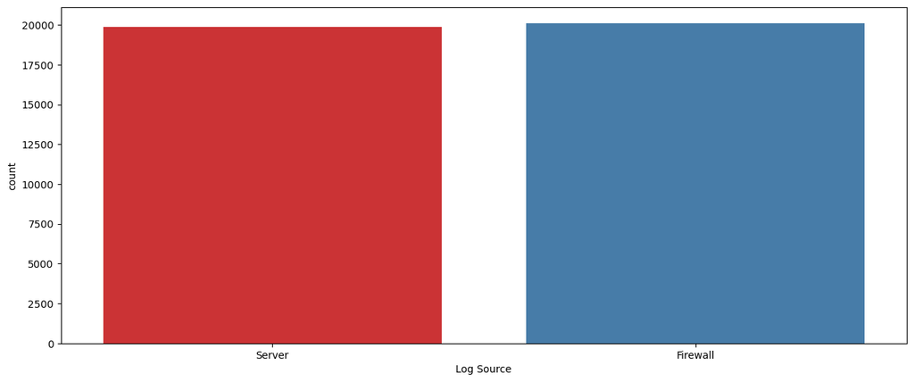

```python
# EDA(EXPLORATORY DATA ANALYSIS)
matplotlib.pyplot.figure(figsize=(15,6))
seaborn.countplot(x='Log Source',data=Dataset,palette='Set1')
matplotlib.pyplot.xticks(rotation = 0)
matplotlib.pyplot.show()
```

The above plot represents the count plot for the Log Source column of the dataset.Also we can see that the Firewall attacks are happening slightly more compare to the Server attacks.

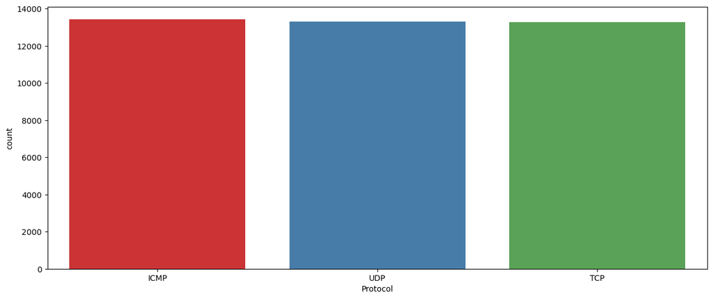

```python
# Result:
matplotlib.pyplot.figure(figsize=(15,6))
seaborn.countplot(x='Protocol',data=Dataset,palette='Set1')
matplotlib.pyplot.xticks(rotation = 0)
matplotlib.pyplot.show()
```

The above plot represents the count plot of protocol column of thr dataset.Also it represents that the protocol column consists of three different classes.Each class consists of similar number of data items.

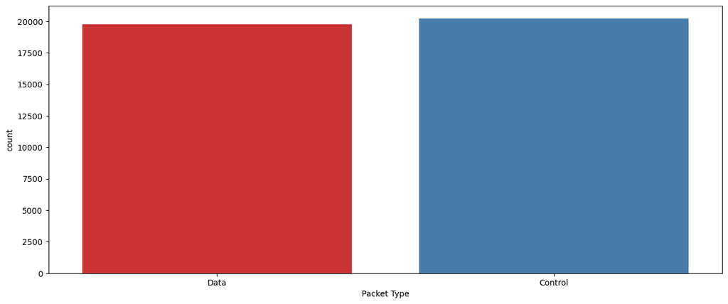

```python
# Result:
matplotlib.pyplot.figure(figsize=(15,6))
seaborn.countplot(x='Packet Type',data=Dataset,palette='Set1')
matplotlib.pyplot.xticks(rotation = 0)
matplotlib.pyplot.show()
```

The above plot represents the count plot of the packet type column of the datset.Also the above plot represents that there are two different classes in the packet type column.And also the control packet type consists of more data items.

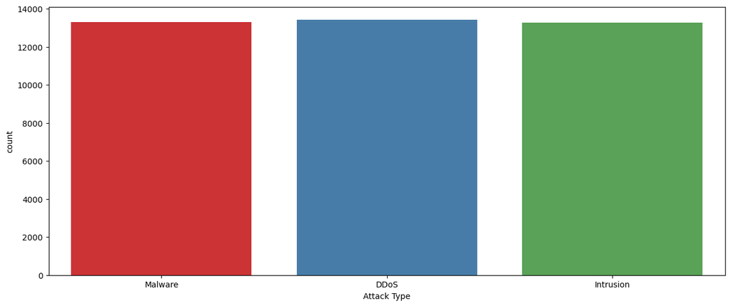

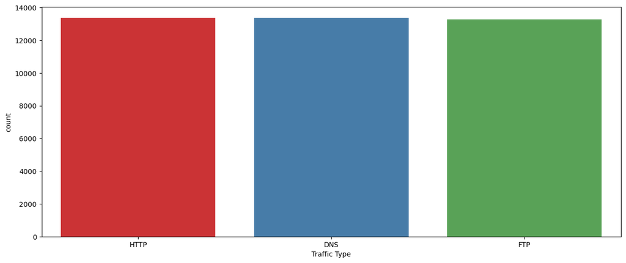

```python
# Result:
matplotlib.pyplot.figure(figsize=(15,6))
seaborn.countplot(x='Attack Type',data=Dataset,palette='Set1')
matplotlib.pyplot.xticks(rotation = 0)
matplotlib.pyplot.show()
matplotlib.pyplot.figure(figsize=(15,6))
seaborn.countplot(x='Traffic Type',data=Dataset,palette='Set1')
matplotlib.pyplot.xticks(rotation = 0)
matplotlib.pyplot.show()
```

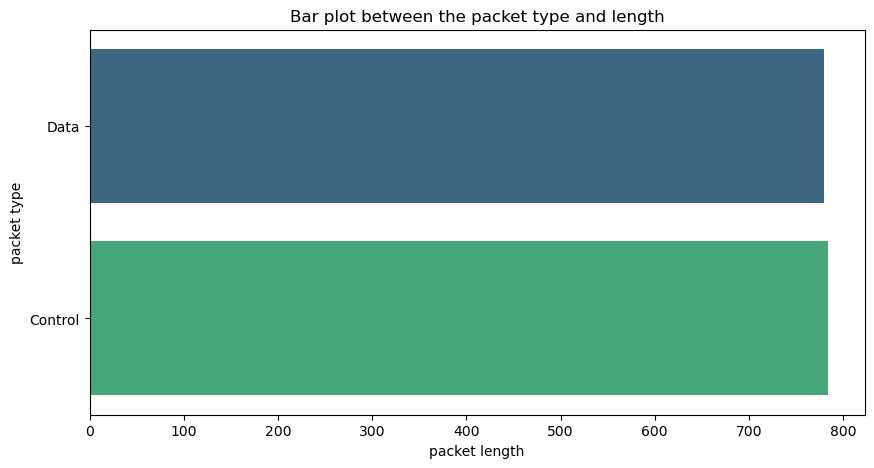

```python
# Gender gap in internet usage by area
matplotlib.pyplot.figure(figsize=(10, 5))
seaborn.barplot(data=Dataset, x='Packet Length', y='Packet Type', ci=None, palette='viridis')
matplotlib.pyplot.title('Bar plot between the packet type and length')
matplotlib.pyplot.xlabel('packet length')
matplotlib.pyplot.ylabel('packet type')
matplotlib.pyplot.show()
```

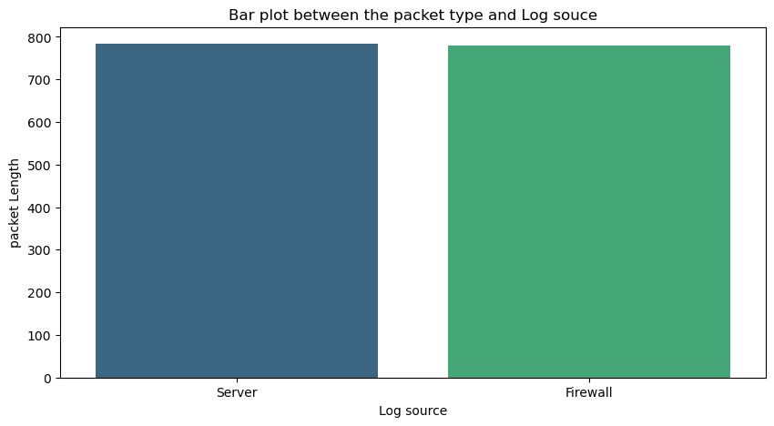

```python
matplotlib.pyplot.figure(figsize=(10, 5))
seaborn.barplot(data=Dataset, x='Log Source', y='Packet Length', ci=None, palette='viridis')
matplotlib.pyplot.title('Bar plot between the packet type and Log souce')
matplotlib.pyplot.xlabel('Log source')
matplotlib.pyplot.ylabel('packet Length')
matplotlib.pyplot.show()
```

The above plot represents the Bar plot between the Log source column and Packet length columns of the dataset.Also it represents that the both classes of Log Source have almost consists of data points.

From the above plots we can conclude that the both the type of attacks are happeneing.Moreover the Firewall cyber attacks are happening more comparerd to the server attacks.